# AED Proyecto

Carlos Galan Valentina Lopez Lucia Ardila

2024-09-21

# Introduccion

Para las aerolíneas, no solo es importante ofrecer un buen servicio, sino también entender las opiniones de sus usuarios. A través de las reseñas, pueden identificar áreas de mejora, analizar comentarios positivos y negativos, y evaluar el impacto de las calificaciones que reciben. En este informe, exploraremos una base de datos de reviews dejadas por los pasajeros, con el objetivo de comprender mejor la percepción del servicio ofrecido por distintas aerolíneas.

La base de datos utilizada en este proyecto proviene de Kaggle:https://www.kaggle.com/datasets/juhibhojani/airline-reviews, y originalmente no contenía información cuantitativa continua. Por esta razón, se decidió incorporar columnas adicionales como vader_pos, roberta_pos, vader_neg, entre otras, generadas mediante modelos de análisis de sentimientos como VADER y Roberta. Estos modelos permiten capturar de manera precisa el tono emocional de las reseñas, agregando valor al análisis al ofrecer una interpretación más detallada de las experiencias de los usuarios y su influencia en las calificaciones generales. Sin embargo, cabe resaltar que, aunque estas variables aportan contexto, el enfoque central del proyecto es estrectamente estadístico, no de análisis de sentimientos.

## Base de datos

```r
library(readxl)
df_1_ <- read_excel("C:/Users/sCAGP/OneDrive - Universidad del rosario/Escritorio/proba/df (1).xlsx")
head(df_1_)
```

| vader_neg | vader_neu | vader_pos | vader_compound | roberta_neg | roberta_neu | roberta_pos | Airline_Name | Overall_Rating | Verified | Review | Type_Of_Traveller | Seat_Type | Seat_Comfort | Cabin_Staff_Service | Food_&_Beverages | Value_For_Money | Recommended | Review_Length | subjectivity | Average_Rating |
| --- | --- | --- | --- | --- | --- | --- | --- | --- | --- | --- | --- | --- | --- | --- | --- | --- | --- | --- | --- | --- |
| 0.005 | 0.886 | 0.110 | 0.9889 | 0.006316306 | 0.113887809 | 0.87979585 | ANA All Nippon Airways | 5 | TRUE | Jakarta to Tokyo Narita on 13th January 2021 on the way home to Houston after a SE Asia trip. Checked in online and was able to secure bulkhead seats. Bag drop counter person worked very quick and pro… | Family Leisure | Premium Economy | 5 | 5 | 4 | 4 | yes | 1746 | 0.4833333 | 4.50 |
| 0.054 | 0.905 | 0.041 | -0.2500 | 0.906834066 | 0.082431853 | 0.01073407 | ANA All Nippon Airways | 2 | TRUE | Can't expect much for premium economy so the seat, meal and inflight entertainment was fine. What was horrible is the policy to require mask in a 14h flight. What made it worse was the flight was midn… | Solo Leisure | Premium Economy | 4 | 2 | 4 | 1 | no | 434 | 0.5725000 | 2.75 |
| 0.000 | 0.536 | 0.464 | 0.9779 | 0.001654336 | 0.009690544 | 0.98865509 | ANA All Nippon Airways | 1 | TRUE | Los Angeles to Ho Chi Minh City via Tokyo. This is the best airline company. Everything is good. Customer service is the best. Aircrew is super good and helpful, professional. The food is the best etc… | Family Leisure | Economy Class | 5 | 5 | 5 | 5 | yes | 203 | 0.4095238 | 5.00 |
| 0.045 | 0.859 | 0.096 | 0.6902 | 0.786756814 | 0.192679092 | 0.02056414 | ANA All Nippon Airways | 2 | TRUE | Tokyo to Bangkok in July. Wheelchair passenger have to wait for check-in more than 1 hour at Haneda airport. We had been waiting at Special Assistant line for longer than 30 Minutes, then the line not… | Family Leisure | Economy Class | 5 | 4 | 3 | 2 | no | 571 | 0.4682540 | 3.50 |
| 0.084 | 0.734 | 0.182 | 0.8405 | 0.718445539 | 0.221347421 | 0.06020710 | ANA All Nippon Airways | 4 | TRUE | Pretty disappointed with ANA, especially when compared to JAL. Seats are dated and half are very exposed. The Japanese food was generally good and at times excellent. The champagne was undrinkable. Th… | Business | Business Class | 3 | 4 | 2 | 4 | no | 431 | 0.5653846 | 3.25 |
| 0.112 | 0.854 | 0.034 | -0.6700 | 0.902736902 | 0.082719035 | 0.01454402 | ANA All Nippon Airways | 2 | TRUE | Would probably never recommend this airline to anyone. While their staff are nice and did tried to accommodate us, it made absolutely no sense that we are put on two separate seats again. Twice! First… | Couple Leisure | Economy Class | 1 | 4 | 4 | 4 | no | 415 | 0.6009259 | 3.25 |

```r
num_registros <- nrow(df_1_)
num_columnas <- ncol(df_1_)

cat("Número de registros (filas):", num_registros, "\n")
```

```
## Número de registros (filas): 5120
```

```r
cat("Número de columnas:", num_columnas, "\n")
```

```
## Número de columnas: 21
```

## Diccionario de variables

- **vader_neg**: Variable cuantitativa continua que indica la proporción de negatividad en un comentario según el modelo VADER, con un rango de 0 a 1.
- **vader_neu**: Variable cuantitativa continua que refleja la proporción de neutralidad de un comentario basado en el modelo VADER; valores cercanos a 1 indican ausencia de emociones marcadas.
- **vader_pos**: Variable cuantitativa continua que mide la proporción de positividad en un comentario usando el modelo VADER, donde valores más altos indican un tono predominantemente positivo.
- **vader_compound**: Variable cuantitativa continua que representa un índice de sentimiento en un rango de -1 a 1, calculado por VADER.
- **roberta_neg**: Variable cuantitativa continua que mide la proporción de negatividad en un comentario según el modelo Roberta, con un rango de 0 a 1.
- **roberta_neu**: Variable cuantitativa continua que indica la proporción de neutralidad de un comentario usando el modelo Roberta; valores cercanos a 1 sugieren una ausencia de emociones marcadas.
- **roberta_pos**: Variable cuantitativa continua que refleja la proporción de positividad en un comentario basado en el modelo Roberta, con valores más cercanos a 1 señalando un tono positivo.
- **Airline Name**: Variable cualitativa nominal que indica el nombre de la aerolínea sobre la cual se realiza la reseña.
- **Overall_Rating**: Variable cuantitativa discreta que representa la calificación global otorgada por el usuario a la experiencia de vuelo, con un rango de 1 a 5.
- **Verified**: Variable cualitativa binaria que indica si el usuario que escribió la reseña fue verificado como pasajero real del vuelo.
- **Review**: Variable cualitativa textual que contiene el texto de la reseña que describe la experiencia del usuario.
- **Type of Traveller**: Variable cualitativa nominal que clasifica al usuario según el tipo de viaje realizado.
- **Seat Type**: Variable cualitativa ordinal que indica el tipo de clase en la que viajó el pasajero.
- **Seat Comfort**: Variable cuantitativa discreta que representa la puntuación otorgada por el usuario a la comodidad del asiento, en una escala de 1 a 5.
- **Cabin Staff Service**: Variable cuantitativa discreta que califica el servicio brindado por el personal de cabina, en una escala de 1 a 5.
- **Food & Beverages**: Variable cuantitativa discreta que evalúa la calidad de la comida y las bebidas ofrecidas durante el vuelo, en una escala de 1 a 5.
- **Value for Money**: Variable cuantitativa discreta que mide la percepción del usuario sobre la relación calidad-precio del vuelo.
- **Recommended**: Variable cualitativa binaria que indica si el usuario recomienda o no la aerolínea.
- **Review Length**: Variable cuantitativa discreta que mide la longitud del texto de la reseña.
- **Subjectivity**: Variable cuantitativa continua que representa la proporción de subjetividad en el comentario, calculada utilizando el modelo TextBlob.Valores cercanos a 1 indican una opinión altamente personal(emocional), mientras que valores bajos sugieren un enfoque más objetivo.
- **Average_Rating** Variable cuantitativa continua que muestra el promedio de los ratings Seat Comfort,Cabin Staff Service, Food and Beverages y Value for Money para cada resgistro.

## Estadisticas descriptivas

```r
summary(df_1_)
```

```
##    vader_neg         vader_neu        vader_pos       vader_compound
##  Min.   :0.00000   Min.   :0.4210   Min.   :0.00000   Min.   :-0.99690
##  1st Qu.:0.04500   1st Qu.:0.7610   1st Qu.:0.03400   1st Qu.:-0.85283
##  Median :0.08600   Median :0.8180   Median :0.07300   Median :-0.32785
##  Mean   :0.09346   Mean   :0.8077   Mean   :0.09884   Mean   :-0.07072
##  3rd Qu.:0.13000   3rd Qu.:0.8640   3rd Qu.:0.14000   3rd Qu.: 0.84783
##  Max.   :0.46100   Max.   :1.0000   Max.   :0.55500   Max.   : 0.99840
##   roberta_neg         roberta_neu       roberta_pos       Airline_Name
##  Min.   :0.0009161   Min.   :0.00495   Min.   :0.002041   Length:5120
##  1st Qu.:0.0834985   1st Qu.:0.04259   1st Qu.:0.007772   Class :character
##  Median :0.7745988   Median :0.09442   Median :0.027113   Mode  :character
##  Mean   :0.5857476   Mean   :0.14422   Mean   :0.270036
##  3rd Qu.:0.9238700   3rd Qu.:0.22133   3rd Qu.:0.619630
##  Max.   :0.9838314   Max.   :0.71179   Max.   :0.993384
##  Overall_Rating   Verified          Review          Type_Of_Traveller
##  Min.   :1.000   Mode :logical   Length:5120        Length:5120
##  1st Qu.:1.000   FALSE:1567      Class :character   Class :character
##  Median :1.000   TRUE :3553      Mode  :character   Mode  :character
##  Mean   :1.966
##  3rd Qu.:2.000
##  Max.   :5.000
##   Seat_Type          Seat_Comfort  Cabin_Staff_Service Food_&_Beverages
##  Length:5120        Min.   :1.00   Min.   :1.000       Min.   :1.000
##  Class :character   1st Qu.:1.00   1st Qu.:1.000       1st Qu.:1.000
##  Mode  :character   Median :2.00   Median :3.000       Median :2.000
##                     Mean   :2.61   Mean   :2.821       Mean   :2.453
##                     3rd Qu.:4.00   3rd Qu.:4.000       3rd Qu.:4.000
##                     Max.   :5.00   Max.   :5.000       Max.   :5.000
##  Value_For_Money Recommended        Review_Length     subjectivity
##  Min.   :1.000   Length:5120        Min.   : 116.0   Min.   :0.0000
##  1st Qu.:1.000   Class :character   1st Qu.: 379.0   1st Qu.:0.4309
##  Median :2.000   Mode  :character   Median : 595.5   Median :0.5101
##  Mean   :2.429                      Mean   : 772.8   Mean   :0.5143
##  3rd Qu.:4.000                      3rd Qu.: 983.0   3rd Qu.:0.5928
##  Max.   :5.000                      Max.   :3558.0   Max.   :1.0000
##  Average_Rating
##  Min.   :1.000
##  1st Qu.:1.250
##  Median :2.250
##  Mean   :2.578
##  3rd Qu.:3.750
##  Max.   :5.000
```

Insights relevantes.

*Vader*

- Sentimiento Neutro (vader_neu): La media de 0.808 muestra que la mayoría de las reseñas contienen una gran cantidad de contenido neutral. Esto sugiere que, aunque los clientes mencionan aspectos tanto positivos como negativos, una gran parte del contenido no refleja un sentimiento fuerte. Y esto pudo ser una gran dificultad para los algoritmos de clasificación de sentimiento.
- Sentimiento Negativo (vader_neg): Con una media de 0.093 y una mediana de 0.086, se puede concluir que el contenido negativo es bastante bajo, pero aún está presente.Ademas el máximo de 0.461 muestra que algunas reseñas tienen un contenido negativo significativo, pero este no es el caso general.

Sentimiento Positivo (vader_pos): La media de 0.099 muestra que, en promedio, las reseñas tienen una pequeña proporción de contenido positivo, lo cual es relativamente bajo. El máximo de 0.555 indica que algunas reseñas son muy positivas, aunque representan una minoría tambien.

- VADER Compound (vader_compound): El promedio de -0.071 indica que el sentimiento general de las reseñas tiende a ser ligeramente negativo. Esto puede significar que la mayoría de las reseñas están más inclinadas hacia una insatisfacción leve o un sentimiento neutro-negativo. La mediana de -0.328 refuerza esta idea, ya que la mayoría de las puntuaciones de sentimiento compuesto tienden a estar en el rango negativo. Los extremos (máximo de 0.998 y mínimo de -0.997) indican que, aunque en general las reseñas son neutrales o negativas, existen algunas con sentimientos extremos, tanto positivos como negativos.
- Se observa que el analisis individual de cada variable de vader termina generalizandose en la variable vader compound la cual debe decidir donde clasificar el comentario a pesar de su falta de polaridad.

*Roberta*

- roberta_neg:Con una media de 0.586, RoBERTa detecta un mayor porcentaje de contenido negativo en comparación con VADER. Esto podría deberse a diferencias en cómo los dos modelos interpretan el tono de las reseñas. Pues roberta es mucho mas robusto y vader está diseñado para textos no muy complejos.
- roberta_neu: La media de 0.144 muestra una baja proporción de contenido neutral según RoBERTa, lo que es bastante diferente del análisis de VADER, que detectaba mucho más contenido neutral.
- roberta_pos: La media de 0.270 indica que RoBERTa encuentra más contenido positivo en comparación con VADER, pero aún es menos común que el contenido negativo. Ademas el máximo de 0.993 sugiere que algunas reseñas son extremadamente positivas, similar a lo observado en VADER.
- Las valoraciones generales son bajas, y una gran parte de los usuarios no recomendarían la aerolínea.
- Las reseñas son en su mayoria largas y subjetivas.
- VADER tiende a clasificar muchas reseñas como neutrales y tiene dificultades para capturar sentimientos más complejos, especialmente en reseñas largas o complejas. Esto lo hace menos preciso en este tipo de textos.
- RoBERTa, por otro lado, detecta una mayor proporción de contenido negativo y positivo, con menos contenido neutral, lo que lo convierte en un modelo más robusto para analizar reseñas que contienen emociones más complejas.

# Graficas

## Cualitativas

### Diagramas de barras

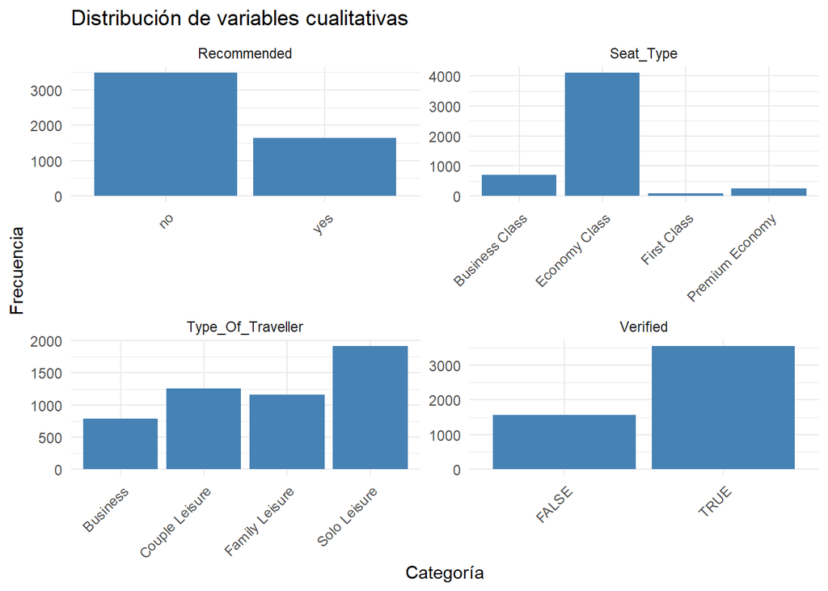

```r
library(ggplot2)
library(dplyr)
library(tidyr)
cualitativas <- df_1_ %>%
  select(Type_Of_Traveller, Seat_Type, Recommended, Verified)

cualitativas_largo <- gather(cualitativas, key = "Variable", value = "Valor")

ggplot(cualitativas_largo, aes(x = Valor)) +
  geom_bar(fill = "steelblue") +
  facet_wrap(~ Variable, scales = "free") +
  theme_minimal() +
  theme(axis.text.x = element_text(angle = 45, hjust = 1)) +
  labs(title = "Distribución de variables cualitativas", x = "Categoría", y = "Frecuencia")
```

- En la primera grafica muestra que la mayoría de los usuarios no recomendaron el servicio, por lo que en teoria los modelos de predicción de vader y roberta deberían haber clasificado un sentimiento en su mayoría negativo.
- El gran sesgo hacia la “Economy Class” es coherente puesto que es la clase con mas limitaciones debido a su precio.
- La predominancia de viajeros especialmente los que viajan solos, puede sugerir que el servicio tiene más demanda entre turistas o viajeros ocasionales, en lugar de ejecutivos o viajeros de negocios. Esto puede ser de para estrategias de segmentación de mercado.
- la mayoría de las opiniones en este conjunto de datos son de usuarios cuya identidad o compra ha sido confirmada, lo que podría darle más credibilidad al análisis de las opiniones.

### diagramas de barras apilados

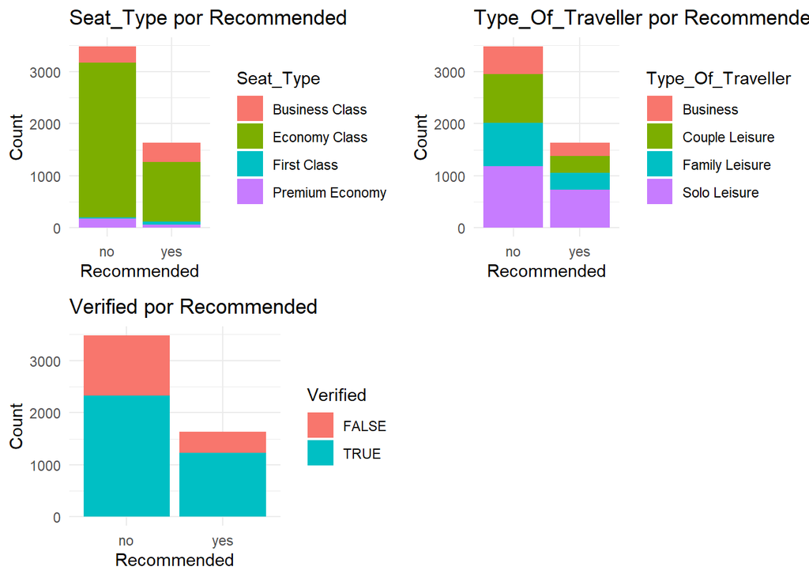

```r
library(ggplot2)
library(dplyr)
library(gridExtra)
df_1_$Recommended <- as.factor(df_1_$Recommended)
df_1_$Verified <- as.factor(df_1_$Verified)


g1 <- ggplot(df_1_, aes(x = Recommended, fill = Seat_Type)) +
  geom_bar(position = "stack") +
  labs(title = "Seat_Type por Recommended",
       x = "Recommended",
       y = "Count",
       fill = "Seat_Type") +
  theme_minimal()


g2 <- ggplot(df_1_, aes(x = Recommended, fill = Type_Of_Traveller)) +
  geom_bar(position = "stack") +
  labs(title = "Type_Of_Traveller por Recommended",
       x = "Recommended",
       y = "Count",
       fill = "Type_Of_Traveller") +
  theme_minimal()


g3 <- ggplot(df_1_, aes(x = Recommended, fill = Verified)) +
  geom_bar(position = "stack") +
  labs(title = "Verified por Recommended",
       x = "Recommended",
       y = "Count",
       fill = "Verified") +
  theme_minimal()

# Colocar los gráficos en una disposición personalizada (2 en la primera fila y 1 en la segunda fila)
grid.arrange(g1, g2, g3, layout_matrix = rbind(c(1, 2), c(3, NA)))
```

### Treemaps

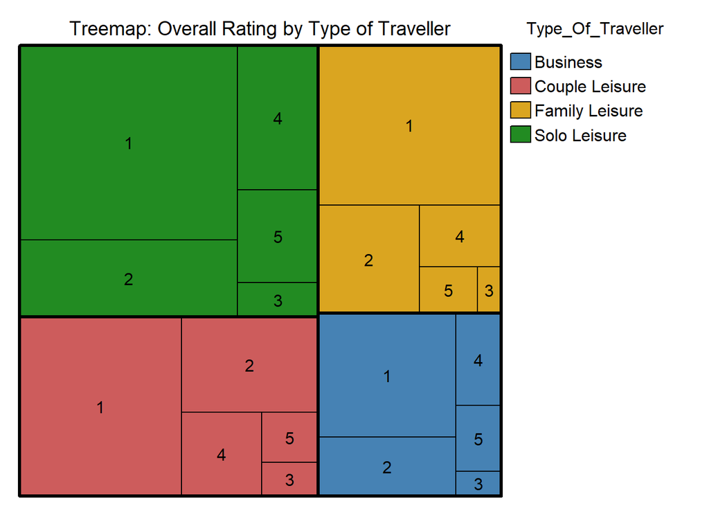

```r
library(treemap)
library(dplyr)


df_summary <- df_1_ %>%
  group_by(Type_Of_Traveller, Overall_Rating) %>%
  summarise(Count = n()) %>%
  ungroup()
treemap(df_summary,
        index = c("Type_Of_Traveller", "Overall_Rating"),    # Definir la jerarquía
        vSize = "Count",                                     # Tamaño según el conteo de ratings
        vColor = "Type_Of_Traveller",                        # Colores distintos para cada tipo de viajero
        type = "categorical",                                # El color representa cada categoría
        palette = c("steelblue", "indianred", "goldenrod", "forestgreen"), # Colores para cada categoría
        fontsize.labels = c(0, 12),                          # Oculta el primer nivel, muestra Overall_Rating y Count
        fontcolor.labels = "black",                          # Define el color de la fuente como negro
        align.labels = list(c("center", "center"), c("center", "center")), # Centra las etiquetas
        title = "Treemap: Overall Rating by Type of Traveller", # Título del gráfico
        title.legend = "Type_Of_Traveller")                  # Muestra la leyenda del tipo de viajero
```

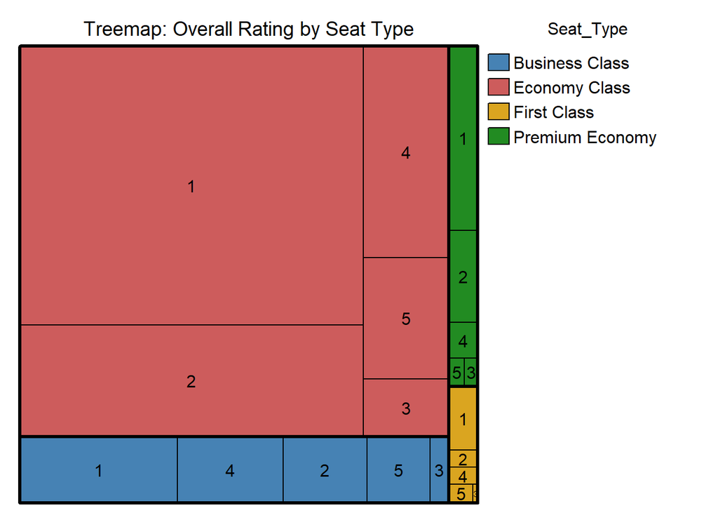

```r
df_summary <- df_1_ %>%
  group_by(Seat_Type, Overall_Rating) %>%
  summarise(Count = n()) %>%
  ungroup()
treemap(df_summary,
        index = c("Seat_Type", "Overall_Rating"),
        vSize = "Count",
        vColor = "Seat_Type",
        type = "categorical",
        palette = c("steelblue", "indianred", "goldenrod", "forestgreen"),
        fontsize.labels = c(0, 12),
        fontcolor.labels = "black",
        align.labels = list(c("center", "center"), c("center", "center")),
        title = "Treemap: Overall Rating by Seat Type",
        title.legend = "Seat_Type")
```

- Los pasajeros en Economy Class tienden a dar las calificaciones más bajas, lo cual podría reflejar una menor satisfacción en comparación con otras clases, mientras que Business Class muestra una experiencia más equilibrada.

### Boxplots

#### Boxplots comparando vader_compound con cuantitativas

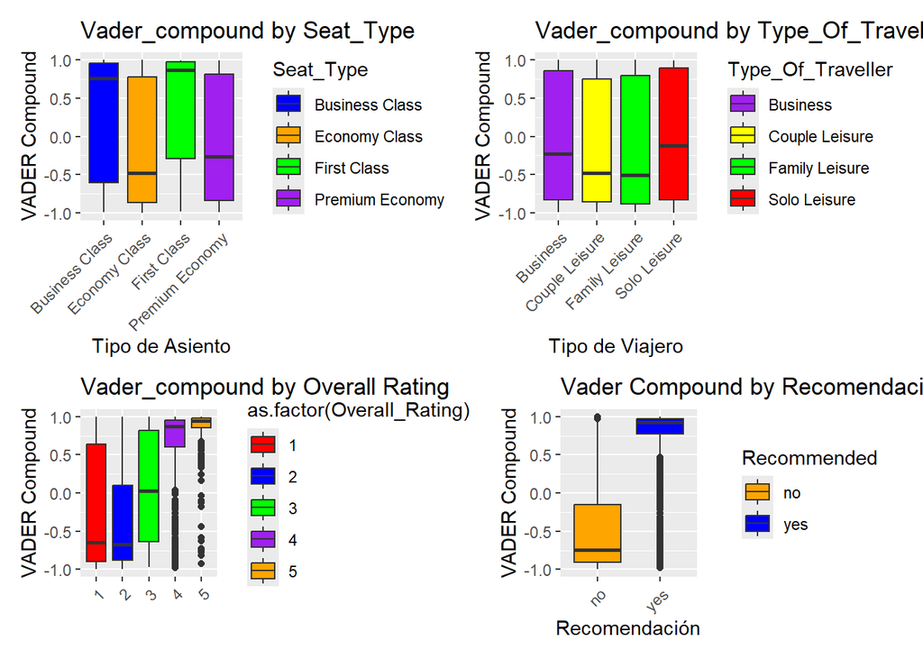

```r
library(ggplot2)
library(patchwork)
g2 <- ggplot(df_1_, aes(x = Seat_Type, y = vader_compound, fill = Seat_Type)) +
  geom_boxplot() +
  labs(title = "Vader_compound by Seat_Type",
       x = "Tipo de Asiento", y = "VADER Compound") +
  scale_fill_manual(values = c("Premium Economy" = "purple",
                               "Economy Class" = "orange",
                               "Business Class" = "blue",
                               "First Class" = "green")) +
  theme(axis.text.x = element_text(angle = 45, hjust = 1))

g3 <- ggplot(df_1_, aes(x = Type_Of_Traveller, y = vader_compound, fill = Type_Of_Traveller)) +
  geom_boxplot() +
  labs(title = "Vader_compound by Type_Of_Traveller",
       x = "Tipo de Viajero", y = "VADER Compound") +
  scale_fill_manual(values = c("Family Leisure" = "green",
                               "Solo Leisure" = "red",
                               "Business" = "purple",
                               "Couple Leisure" = "yellow")) +
  theme(axis.text.x = element_text(angle = 45, hjust = 1))

g5 <- ggplot(df_1_, aes(x = as.factor(Overall_Rating), y = vader_compound, fill = as.factor(Overall_Rating))) +
  geom_boxplot() +
  labs(title = "Vader_compound by Overall Rating",
       x = "",
       y = "VADER Compound") +
  scale_fill_manual(values = c("1" = "red", "2" = "blue",
                               "3" = "green", "4" = "purple",
                               "5" = "orange")) +
  theme(axis.text.x = element_text(angle = 45, hjust = 1))

g6 <- ggplot(df_1_, aes(x = Recommended, y = vader_compound, fill = Recommended)) +
  geom_boxplot() +
  labs(title = "Vader Compound by Recomendación",
       x = "Recomendación", y = "VADER Compound") +
  scale_fill_manual(values = c("yes" = "blue", "no" = "orange")) +
  theme(axis.text.x = element_text(angle = 45, hjust = 1))

(g2 | g3) / (g5 | g6)
```

#### Boxplots comparando Average_Rating con cuantitativas

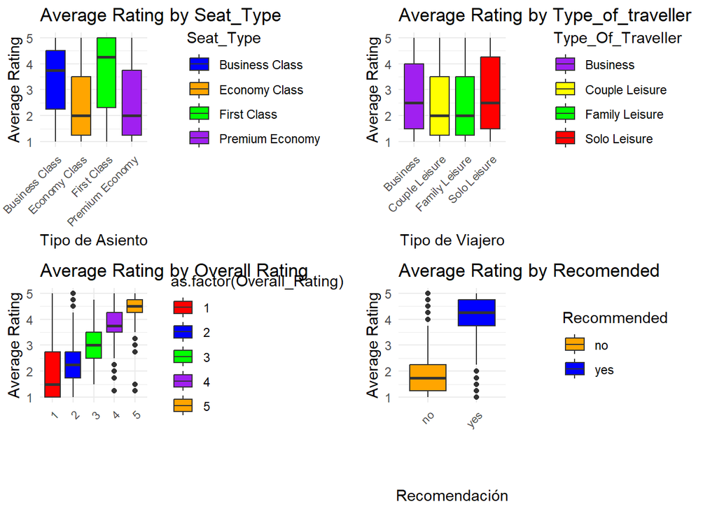

```r
library(ggplot2)
library(cowplot)
g2_avg <- ggplot(df_1_, aes(x = Seat_Type, y = Average_Rating, fill = Seat_Type)) +
  geom_boxplot() +
  labs(title = "Average Rating by Seat_Type",
       x = "Tipo de Asiento", y = "Average Rating") +
  scale_fill_manual(values = c("Premium Economy" = "purple",
                               "Economy Class" = "orange",
                               "Business Class" = "blue",
                               "First Class" = "green")) +
  theme_minimal() +
  theme(axis.text.x = element_text(angle = 45, hjust = 1, size = 8),
        plot.margin = margin(5, 5, 5, 5))

g3_avg <- ggplot(df_1_, aes(x = Type_Of_Traveller, y = Average_Rating, fill = Type_Of_Traveller)) +
  geom_boxplot() +
  labs(title = "Average Rating by Type_of_traveller",
       x = "Tipo de Viajero", y = "Average Rating") +
  scale_fill_manual(values = c("Family Leisure" = "green",
                               "Solo Leisure" = "red",
                               "Business" = "purple",
                               "Couple Leisure" = "yellow")) +
  theme_minimal() +
  theme(axis.text.x = element_text(angle = 45, hjust = 1, size = 8),
        plot.margin = margin(5, 5, 5, 5))

g5_avg <- ggplot(df_1_, aes(x = as.factor(Overall_Rating), y = Average_Rating, fill = as.factor(Overall_Rating))) +
  geom_boxplot() +
  labs(title = "Average Rating by Overall Rating",
       x = "",
       y = "Average Rating") +
  scale_fill_manual(values = c("1" = "red", "2" = "blue",
                               "3" = "green", "4" = "purple",
                               "5" = "orange")) +
  theme_minimal() +
  theme(axis.text.x = element_text(angle = 45, hjust = 1, size = 8),
        plot.margin = margin(5, 5, 5, 5))

g6_avg <- ggplot(df_1_, aes(x = Recommended, y = Average_Rating, fill = Recommended)) +
  geom_boxplot() +
  labs(title = "Average Rating by Recomended",
       x = "Recomendación", y = "Average Rating") +
  scale_fill_manual(values = c("yes" = "blue", "no" = "orange")) +
  theme_minimal() +
  theme(axis.text.x = element_text(angle = 45, hjust = 1, size = 8),
        plot.margin = margin(5, 5, 5, 5))

# Organizar los gráficos en un arreglo 2x2 usando cowplot::plot_grid
plot_grid(g2_avg, g3_avg, g5_avg, g6_avg, ncol = 2, nrow = 2, align = "hv")
```

1. Distribución de Average Rating por Tipo de Asiento (Seat Type)
- Los pasajeros en clases más caras como Business y First Class tienden a otorgar calificaciones más altas, lo que podría indicar una mejor experiencia en esos tipos de asiento en comparación con Economy Class.
2. Distribución de Average Rating por Tipo de Viajero

Los viajeros de negocios y aquellos que viajan solos parecen más satisfechos en general, mientras que aquellos que viajan en pareja o en familia podrían tener experiencias más diversas, lo que se refleja en calificaciones más variadas.

3. Distribución de Average Rating por Puntuación Total
- La calificación promedio está alineada con la puntuación global que los usuarios dan a la experiencia, lo cual es esperable. Esto sugiere consistencia en la percepción general del servicio y las subcategorías evaluadas.
4. Distribución de Average Rating por Recomendación Como es lógico, quienes recomiendan la aerolínea han tenido una experiencia más satisfactoria en general, reflejada en su Average Rating elevado.

## Cuantitativas

```r
library(psych)
```

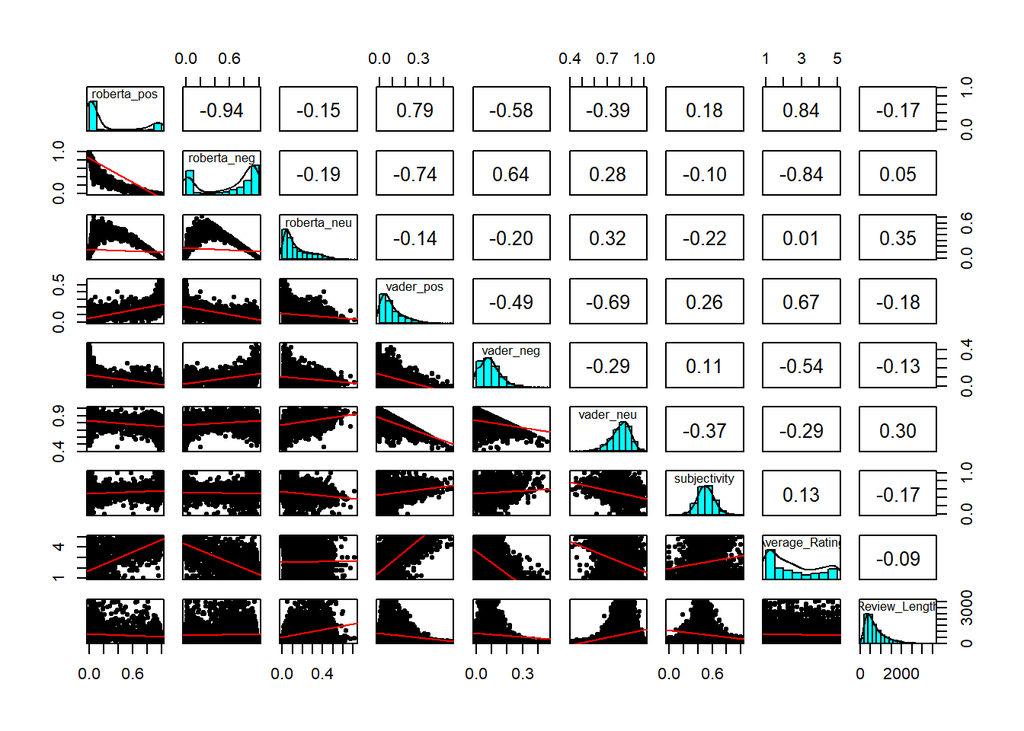

```r
cuantitativas <- df_1_ %>%
  select(roberta_pos, roberta_neg, roberta_neu, vader_pos, vader_neg, vader_neu,subjectivity,Average_Rating,Review_Length)

pairs.panels(cuantitativas,
             ellipses = FALSE,
             lm = TRUE,
             method = "pearson")
```

# Diferencia de medias

Evaluar si los modelos son significativamente diferentes haciendo una prueba de hipotesis para las diferencias de medias entre (vader_pos,roberta_pos),(vader_neu,roberta_neu),(vader_neg,roberta_neu)

1. Prueba t para vader_pos vs roberta_pos
- Hipótesis nula (H₀): No hay diferencia en las medias de vader_pos y roberta_pos (μ₁ - μ₂ = 0).
- Hipótesis alternativa (H₁): Hay una diferencia en las medias de vader_pos y roberta_pos (μ₁ - μ₂ ≠ 0).
2. Prueba t para vader_neu vs roberta_neu
- Hipótesis nula (H₀): No hay diferencia en las medias de vader_neu y roberta_neu (μ₁ - μ₂ = 0).
- Hipótesis alternativa (H₁): Hay una diferencia en las medias de vader_neu y roberta_neu (μ₁ - μ₂ ≠ 0).
3. Prueba t para vader_neg vs roberta_neg
- Hipótesis nula (H₀): No hay diferencia en las medias de vader_neg y roberta_neg (μ₁ - μ₂ = 0).
- Hipótesis alternativa (H₁): Hay una diferencia en las medias de vader_neg y roberta_neg (μ₁ - μ₂ ≠ 0).

```r
# Prueba t para vader_pos vs roberta_pos
t_test_pos <- t.test(df_1_$vader_pos, df_1_$roberta_pos, paired = TRUE)
print(t_test_pos)
```

```
##
##  Paired t-test
##
## data:  df_1_$vader_pos and df_1_$roberta_pos
## t = -38.772, df = 5119, p-value < 2.2e-16
## alternative hypothesis: true mean difference is not equal to 0
## 95 percent confidence interval:
##  -0.179849 -0.162537
## sample estimates:
## mean difference
##       -0.171193
```

```r
# Prueba t para vader_neu vs roberta_neu
t_test_neu <- t.test(df_1_$vader_neu, df_1_$roberta_neu, paired = TRUE)
print(t_test_neu)
```

```
##
##  Paired t-test
##
## data:  df_1_$vader_neu and df_1_$roberta_neu
## t = 370.02, df = 5119, p-value < 2.2e-16
## alternative hypothesis: true mean difference is not equal to 0
## 95 percent confidence interval:
##  0.6599668 0.6669973
## sample estimates:
## mean difference
##        0.663482
```

```r
# Prueba t para vader_neg vs roberta_neg
t_test_neg <- t.test(df_1_$vader_neg, df_1_$roberta_neg, paired = TRUE)
print(t_test_neg)
```

```
##
##  Paired t-test
##
## data:  df_1_$vader_neg and df_1_$roberta_neg
## t = -102.1, df = 5119, p-value < 2.2e-16
## alternative hypothesis: true mean difference is not equal to 0
## 95 percent confidence interval:
##  -0.5017405 -0.4828364
## sample estimates:
## mean difference
##      -0.4922884
```

## Analisis

- Dado que todos los p-valores son muy bajos (menores que 0.05), puedes rechazar la hipótesis nula en todos los casos, lo que indica que hay diferencias significativas entre las medias de las comparaciones realizadas.
- Los intervalos de confianza te indican que la diferencia media entre las columnas de vader y roberta es significativa, con los intervalos no incluyendo cero.

# Normalidad

## Univariado

- Prueba de normalidad univariada para cada variable usando Anderson-Darling debido a que la muestra es muy grande.

```r
options(repos = c(CRAN = "https://cran.r-project.org"))

install.packages("nortest")
library(nortest)

variables <- c("vader_pos", "roberta_pos", "vader_neu", "roberta_neu", "vader_neg", "roberta_neg","Average_Rating","subjectivity","vader_compound")


for (var in variables) {
    ad_test <- ad.test(df_1_[[var]])
    cat("Prueba de Anderson-Darling para", var, ":\n")
    print(ad_test)
    cat("\n")
}
```

```
## Prueba de Anderson-Darling para vader_pos :
##
##  Anderson-Darling normality test
##
## data:  df_1_[[var]]
## A = 177.91, p-value < 2.2e-16
##
##
## Prueba de Anderson-Darling para roberta_pos :
##
##  Anderson-Darling normality test
##
## data:  df_1_[[var]]
## A = 785.02, p-value < 2.2e-16
##
##
## Prueba de Anderson-Darling para vader_neu :
##
##  Anderson-Darling normality test
##
## data:  df_1_[[var]]
## A = 35.541, p-value < 2.2e-16
##
##
## Prueba de Anderson-Darling para roberta_neu :
##
##  Anderson-Darling normality test
##
## data:  df_1_[[var]]
## A = 245.35, p-value < 2.2e-16
##
##
## Prueba de Anderson-Darling para vader_neg :
##
##  Anderson-Darling normality test
##
## data:  df_1_[[var]]
## A = 49.736, p-value < 2.2e-16
##
##
```

[output cut: 15 more lines]

```
##
## Prueba de Anderson-Darling para subjectivity :
##
##  Anderson-Darling normality test
##
## data:  df_1_[[var]]
## A = 18.141, p-value < 2.2e-16
##
##
## Prueba de Anderson-Darling para vader_compound :
##
##  Anderson-Darling normality test
##
## data:  df_1_[[var]]
## A = 361.7, p-value < 2.2e-16
```

```r
library(MVN)
mardia_test <- mvn(data = df_1_[, variables], mvnTest = "mardia")
print(mardia_test)
```

```
## $multivariateNormality
##              Test        Statistic p value Result
## 1 Mardia Skewness 11290.1473885484       0     NO
## 2 Mardia Kurtosis  25.815629119234       0     NO
## 3             MVN             <NA>    <NA>     NO
##
## $univariateNormality
##               Test       Variable Statistic   p value Normality
## 1 Anderson-Darling   vader_pos     177.9148  <0.001      NO
## 2 Anderson-Darling  roberta_pos    785.0219  <0.001      NO
## 3 Anderson-Darling   vader_neu      35.5412  <0.001      NO
## 4 Anderson-Darling  roberta_neu    245.3512  <0.001      NO
## 5 Anderson-Darling   vader_neg      49.7359  <0.001      NO
## 6 Anderson-Darling  roberta_neg    424.5625  <0.001      NO
## 7 Anderson-Darling Average_Rating  182.9504  <0.001      NO
## 8 Anderson-Darling  subjectivity    18.1409  <0.001      NO
## 9 Anderson-Darling vader_compound  361.6994  <0.001      NO
##
## $Descriptives
##                   n        Mean    Std.Dev      Median          Min       Max
## vader_pos      5120  0.09884258 0.08972136  0.07300000  0.000000000 0.5550000
## roberta_pos    5120  0.27003559 0.38211073  0.02711293  0.002040528 0.9933838
## vader_neu      5120  0.80769883 0.08189853  0.81800000  0.421000000 1.0000000
## roberta_neu    5120  0.14421679 0.12850964  0.09441558  0.004949595 0.7117927
## vader_neg      5120  0.09345918 0.06792028  0.08600000  0.000000000 0.4610000
## roberta_neg    5120  0.58574762 0.38466558  0.77459884  0.000916101 0.9838314
## Average_Rating 5120  2.57802734 1.35797681  2.25000000  1.000000000 5.0000000
## subjectivity   5120  0.51429657 0.14000852  0.51005952  0.000000000 1.0000000
## vader_compound 5120 -0.07071637 0.78781868 -0.32785000 -0.996900000 0.9984000
##                        25th      75th        Skew   Kurtosis
## vader_pos       0.034000000 0.1400000  1.39012578  2.0086658
## roberta_pos     0.007771847 0.6196304  1.02922729 -0.7607051
## vader_neu       0.761000000 0.8640000 -0.75216145  0.9584467
## roberta_neu     0.042591861 0.2213328  1.10941730  0.3751586
## vader_neg       0.045000000 0.1300000  0.98397591  1.5689879
## roberta_neg     0.083498528 0.9238700 -0.57090043 -1.4034040
## Average_Rating  1.250000000 3.7500000  0.47928848 -1.1788678
## subjectivity    0.430904605 0.5928355  0.09740628  1.4657563
## vader_compound -0.852825000 0.8478250  0.21510877 -1.7069392
```

## Bivariado

```r
install.packages("MVN")
library(MVN)

mardia_test <- mvn(data = df_1_[, variables], mvnTest = "mardia")
print(mardia_test)
```

```
## $multivariateNormality
##              Test        Statistic p value Result
## 1 Mardia Skewness 11290.1473885484       0     NO
## 2 Mardia Kurtosis  25.815629119234       0     NO
## 3             MVN             <NA>    <NA>     NO
##
## $univariateNormality
##               Test       Variable Statistic   p value Normality
## 1 Anderson-Darling   vader_pos     177.9148  <0.001      NO
## 2 Anderson-Darling  roberta_pos    785.0219  <0.001      NO
## 3 Anderson-Darling   vader_neu      35.5412  <0.001      NO
## 4 Anderson-Darling  roberta_neu    245.3512  <0.001      NO
## 5 Anderson-Darling   vader_neg      49.7359  <0.001      NO
## 6 Anderson-Darling  roberta_neg    424.5625  <0.001      NO
## 7 Anderson-Darling Average_Rating  182.9504  <0.001      NO
## 8 Anderson-Darling  subjectivity    18.1409  <0.001      NO
## 9 Anderson-Darling vader_compound  361.6994  <0.001      NO
##
## $Descriptives
##                   n        Mean    Std.Dev      Median          Min       Max
## vader_pos      5120  0.09884258 0.08972136  0.07300000  0.000000000 0.5550000
## roberta_pos    5120  0.27003559 0.38211073  0.02711293  0.002040528 0.9933838
## vader_neu      5120  0.80769883 0.08189853  0.81800000  0.421000000 1.0000000
## roberta_neu    5120  0.14421679 0.12850964  0.09441558  0.004949595 0.7117927
## vader_neg      5120  0.09345918 0.06792028  0.08600000  0.000000000 0.4610000
## roberta_neg    5120  0.58574762 0.38466558  0.77459884  0.000916101 0.9838314
## Average_Rating 5120  2.57802734 1.35797681  2.25000000  1.000000000 5.0000000
## subjectivity   5120  0.51429657 0.14000852  0.51005952  0.000000000 1.0000000
## vader_compound 5120 -0.07071637 0.78781868 -0.32785000 -0.996900000 0.9984000
##                        25th      75th        Skew   Kurtosis
## vader_pos       0.034000000 0.1400000  1.39012578  2.0086658
## roberta_pos     0.007771847 0.6196304  1.02922729 -0.7607051
## vader_neu       0.761000000 0.8640000 -0.75216145  0.9584467
## roberta_neu     0.042591861 0.2213328  1.10941730  0.3751586
## vader_neg       0.045000000 0.1300000  0.98397591  1.5689879
## roberta_neg     0.083498528 0.9238700 -0.57090043 -1.4034040
## Average_Rating  1.250000000 3.7500000  0.47928848 -1.1788678
## subjectivity    0.430904605 0.5928355  0.09740628  1.4657563
## vader_compound -0.852825000 0.8478250  0.21510877 -1.7069392
```

Las variable NO se distribuye normal ni de forma univariada ni bivariada.

# KMO y Barlet

```r
# Filtrar solo columnas numéricas
num_data <- df_1_[, sapply(df_1_, is.numeric)]


continuous_columns <- c("vader_neg", "vader_pos", "vader_compound",
                        "roberta_neg", "roberta_pos", "Average_Rating","Review_Length","subjectivity","vader_neu")

num_data <- df_1_[, continuous_columns]
library(psych)
library(REdaS)
kmo_result <- KMO(cor(num_data))
print(kmo_result)
```

```
## Kaiser-Meyer-Olkin factor adequacy
## Call: KMO(r = cor(num_data))
## Overall MSA =  0.7
## MSA for each item =
##      vader_neg      vader_pos vader_compound    roberta_neg    roberta_pos
##           0.49           0.60           0.95           0.80           0.81
## Average_Rating  Review_Length   subjectivity      vader_neu
##           0.97           0.54           0.93           0.37
```

```r
#indep vs no indep (deberia rechazar)
bartlett_result <- bart_spher(num_data)
print(bartlett_result)
```

```
##  Bartlett's Test of Sphericity
##
## Call: bart_spher(x = num_data)
##
##      X2 = 88271.589
##      df = 36
## p-value < 2.22e-16
```

- KMO dió un resultado de 0.7 lo cual indica que se pasó este test para hacer analisis de PCA para las variables elegidas.
- Es importante resaltar que se tuvo que quitar roberta neu, debido a que generaban valores bajos de KMO pues casi no hubo reviews en roberta que hayan tenido una representación alta de comentarios neutrales.
- Barlet pasó tambien la prueba pues rechazó la hipotesis nula de que son variables independeintes. Es decir las variables son significativamente dependientes y podemos usar PCA para reducir su dimensionalidad.

# PCA

```r
scaled_data <- scale(num_data)

# --- Análisis PCA ---
pca_result <- prcomp(scaled_data, center = TRUE, scale. = TRUE)

# Visualización de la varianza explicada
library(factoextra)
```

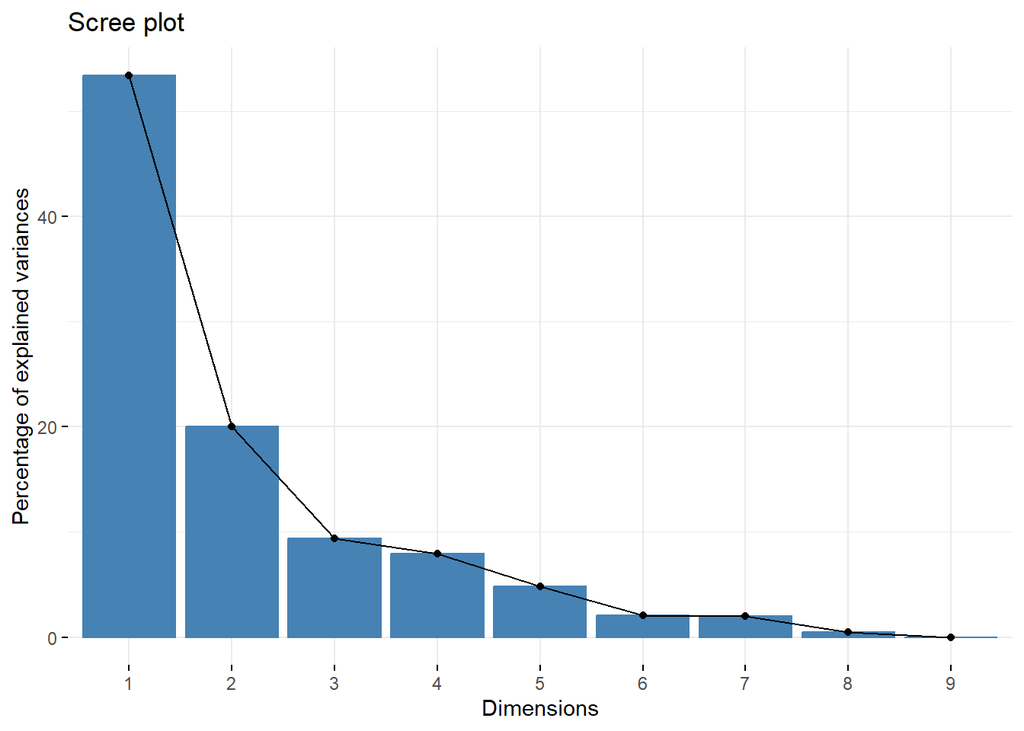

```r
fviz_eig(pca_result)
```

Con base en el punto de codo, se consideró usar 2 componentes principales para capturar la mayor parte de la varianza y reducir la dimensionalidad en la que nos encontramos.

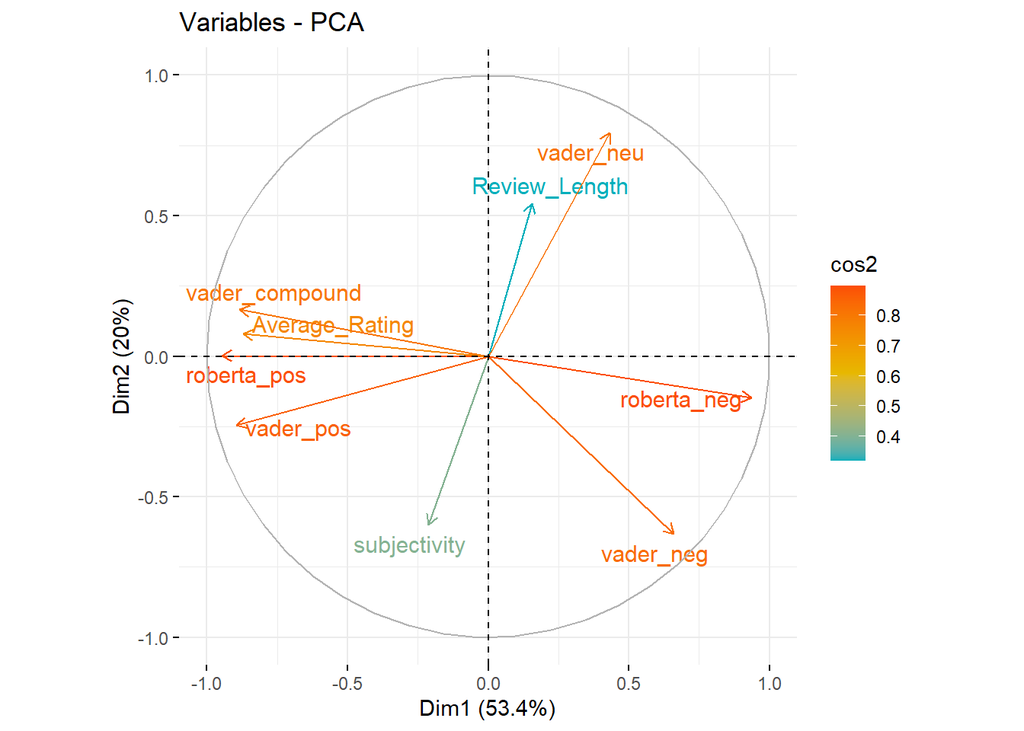

```r
# Gráfico del plano factorial de las variables
fviz_pca_var(pca_result,
             col.var = "cos2",
             gradient.cols = c("#00AFBB", "#E7B800", "#FC4E07"),
             repel = TRUE)
```

- Las variables positivas (vader_pos, roberta_pos) y las negativas (vader_neg, roberta_neg) están claramente separadas, indicando que los componentes principales capturan esta polaridad.
- Dim1 parece estar relacionado con la polaridad del sentimiento, mientras que Dim2 captura la neutralidad y la longitud del comentario.

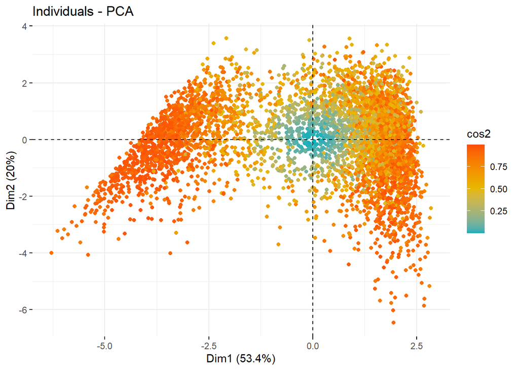

```r
# Visualización del PCA en 2 dimensiones
fviz_pca_ind(pca_result, geom.ind = "point", col.ind = "cos2",
             gradient.cols = c("#00AFBB", "#E7B800", "#FC4E07"),
             repel = TRUE)
```

```r
print(pca_result)
```

```
## Standard deviations (1, .., p=9):
## [1] 2.192422993 1.342858388 0.916976410 0.843082030 0.658886077 0.428869801
## [7] 0.423963101 0.201405621 0.003258426
##
## Rotation (n x k) = (9 x 9):
##                        PC1          PC2          PC3          PC4          PC5
## vader_neg       0.30128524 -0.470910448 -0.057093709  0.287860045  0.381991335
## vader_pos      -0.40804621 -0.183359178 -0.072154479  0.216328597 -0.408388620
## vader_compound -0.40320612  0.124049157  0.031142337 -0.041314268 -0.417589566
## roberta_neg     0.42704681 -0.110094329  0.010899838 -0.023360506 -0.292026681
## roberta_pos    -0.43207309  0.001509734  0.038771493  0.009681112  0.296319218
## Average_Rating -0.39730562  0.059799449  0.003031556  0.002344763  0.567483793
## Review_Length   0.07086235  0.404962527 -0.847722368  0.325237107  0.027596871
## subjectivity   -0.09663418 -0.447033567 -0.504258071 -0.732036048 -0.004367827
## vader_neu       0.19718718  0.591355980  0.126584173 -0.475742345  0.130449711
##                         PC6          PC7          PC8           PC9
## vader_neg      -0.132125794  0.444414989 -0.048047978  4.880159e-01
## vader_pos       0.141456250 -0.373469121  0.077665737  6.446480e-01
## vader_compound  0.034688010  0.789394072 -0.143640513 -1.117969e-04
## roberta_neg     0.488479491 -0.067761495 -0.690190022 -2.381342e-04
## roberta_pos    -0.455168910 -0.172193813 -0.697910515 -4.837151e-05
## Average_Rating  0.716368708  0.057456620  0.005859637 -3.180484e-05
## Review_Length  -0.015315382  0.025526062 -0.070169454  9.822383e-05
## subjectivity   -0.008865572  0.004813884  0.023430662  3.929399e-05
## vader_neu      -0.045181981  0.040679063 -0.045589366  5.884465e-01
```

- Los datos están separados en función de la polaridad (Dim1) y otras características secundarias como longitud y neutralidad (Dim2).
- La mayoría de los individuos están dispersos a lo largo de este eje(dim1), reflejando que la polaridad es la característica más importante en los datos.

# K-means

Se quiso probar k-means para k=3 para mirar si podemos encontrar infomacion sobre la neutralidad de los comentarios.

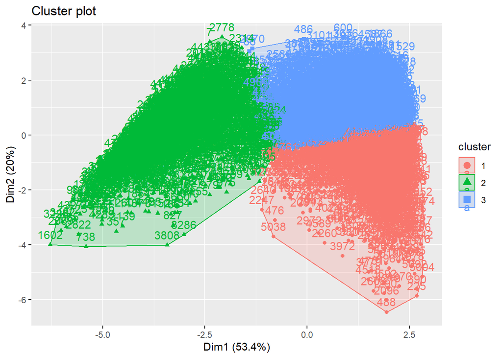

```r
# k-means con el número óptimo de clusters
set.seed(123)
kmeans_result <- kmeans(scaled_data, centers = 3, nstart = 25)

# Visualización de los resultados del k-means
fviz_cluster(kmeans_result, data = scaled_data)
```

# Analisis factorial

Se decidió hacer 2 modelos para analisis factorial:

modelo 1: solo involucra variables respecto a Vader y otras variables relevantes para el analisis.

modelo 2: solo involucra variables respecto a Roberta y otras variables relevantes para el analisis.

```r
# Cargar librerías necesarias
library(psych)
library(factoextra)

# --- Modelo 1 ---
# Variables seleccionadas para el modelo 1
continuous_columns_model1 <- c("vader_neg", "vader_pos", "vader_compound",
                               "Average_Rating", "Review_Length", "subjectivity")

# Filtrar y escalar los datos para el modelo 1
scaled_data_model1 <- scale(df_1_[, continuous_columns_model1])

# Evaluar KMO para justificar el análisis factorial
KMO_result_model1 <- KMO(cor(scaled_data_model1))
print(KMO_result_model1)
```

```
## Kaiser-Meyer-Olkin factor adequacy
## Call: KMO(r = cor(scaled_data_model1))
## Overall MSA =  0.76
## MSA for each item =
##      vader_neg      vader_pos vader_compound Average_Rating  Review_Length
##           0.73           0.76           0.73           0.88           0.55
##   subjectivity
##           0.56
```

```r
if (KMO_result_model1$MSA > 0.6) {
  # Realizar análisis factorial
  fa_result_model1 <- fa(scaled_data_model1, nfactors = 2, rotate = "varimax")
  print(fa_result_model1)
  fa.diagram(fa_result_model1)
}
```

```
## Factor Analysis using method =  minres
## Call: fa(r = scaled_data_model1, nfactors = 2, rotate = "varimax")
## Standardized loadings (pattern matrix) based upon correlation matrix
##                  MR1   MR2   h2   u2 com
## vader_neg      -0.83  0.38 0.84 0.16 1.4
## vader_pos       0.79  0.45 0.82 0.18 1.6
## vader_compound  0.90  0.11 0.83 0.17 1.0
## Average_Rating  0.74  0.19 0.59 0.41 1.1
## Review_Length  -0.03 -0.37 0.14 0.86 1.0
## subjectivity    0.06  0.45 0.20 0.80 1.0
##
##                        MR1  MR2
## SS loadings           2.69 0.73
## Proportion Var        0.45 0.12
## Cumulative Var        0.45 0.57
## Proportion Explained  0.79 0.21
## Cumulative Proportion 0.79 1.00
##
## Mean item complexity =  1.2
## Test of the hypothesis that 2 factors are sufficient.
##
## df null model =  15  with the objective function =  2.61 with Chi Square =  13374.91
## df of  the model are 4  and the objective function was  0
##
## The root mean square of the residuals (RMSR) is  0.01
## The df corrected root mean square of the residuals is  0.01
##
## The harmonic n.obs is  5120 with the empirical chi square  4.89  with prob <  0.3
## The total n.obs was  5120  with Likelihood Chi Square =  16.9  with prob <  0.002
##
## Tucker Lewis Index of factoring reliability =  0.996
## RMSEA index =  0.025  and the 90 % confidence intervals are  0.014 0.038
## BIC =  -17.26
## Fit based upon off diagonal values = 1
## Measures of factor score adequacy
##                                                    MR1  MR2
## Correlation of (regression) scores with factors   0.96 0.85
## Multiple R square of scores with factors          0.93 0.71
## Minimum correlation of possible factor scores     0.86 0.43
```

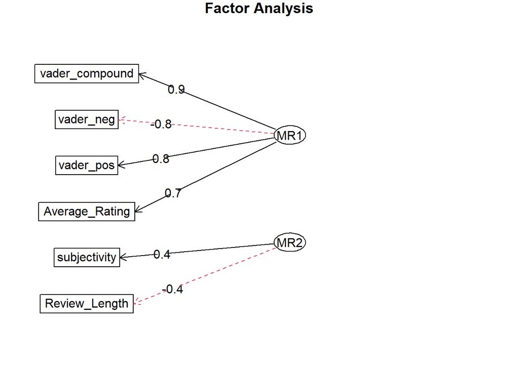

Analisis facorial para el modelo VADER:

- Factor 1 (MR1): Representa el eje emocional (positividad/negatividad) que explica la percepción general y las calificaciones.
- Factor 2 (MR2): Captura características relacionadas con la subjetividad y la longitud de los comentarios.

```r
# --- Modelo 2 ---
# Variables seleccionadas para el modelo 2
continuous_columns_model2 <- c("roberta_neg", "roberta_pos",
                               "Average_Rating", "Review_Length", "subjectivity")

# Filtrar y escalar los datos para el modelo 2
scaled_data_model2 <- scale(df_1_[, continuous_columns_model2])

# Evaluar KMO para justificar el análisis factorial
KMO_result_model2 <- KMO(cor(scaled_data_model2))
print(KMO_result_model2)
```

```
## Kaiser-Meyer-Olkin factor adequacy
## Call: KMO(r = cor(scaled_data_model2))
## Overall MSA =  0.69
## MSA for each item =
##    roberta_neg    roberta_pos Average_Rating  Review_Length   subjectivity
##           0.65           0.65           0.92           0.24           0.56
```

```r
if (KMO_result_model2$MSA > 0.6) {
  # Realizar análisis factorial
  fa_result_model2 <- fa(scaled_data_model2, nfactors = 2, rotate = "varimax")
  print(fa_result_model2)
  fa.diagram(fa_result_model2)

}
```

```
## Factor Analysis using method =  minres
## Call: fa(r = scaled_data_model2, nfactors = 2, rotate = "varimax")
## Standardized loadings (pattern matrix) based upon correlation matrix
##                  MR1   MR2   h2    u2 com
## roberta_neg    -0.98 -0.04 0.97 0.029 1.0
## roberta_pos     0.95  0.27 0.97 0.028 1.2
## Average_Rating  0.84  0.14 0.73 0.269 1.1
## Review_Length  -0.03 -0.50 0.25 0.747 1.0
## subjectivity    0.09  0.33 0.12 0.881 1.2
##
##                        MR1  MR2
## SS loadings           2.59 0.46
## Proportion Var        0.52 0.09
## Cumulative Var        0.52 0.61
## Proportion Explained  0.85 0.15
## Cumulative Proportion 0.85 1.00
##
## Mean item complexity =  1.1
## Test of the hypothesis that 2 factors are sufficient.
##
## df null model =  10  with the objective function =  3.71 with Chi Square =  18974.88
## df of  the model are 1  and the objective function was  0
##
## The root mean square of the residuals (RMSR) is  0
## The df corrected root mean square of the residuals is  0.01
##
## The harmonic n.obs is  5120 with the empirical chi square  0.83  with prob <  0.36
## The total n.obs was  5120  with Likelihood Chi Square =  2.73  with prob <  0.098
##
## Tucker Lewis Index of factoring reliability =  0.999
## RMSEA index =  0.018  and the 90 % confidence intervals are  0 0.046
## BIC =  -5.81
## Fit based upon off diagonal values = 1
## Measures of factor score adequacy
##                                                    MR1  MR2
## Correlation of (regression) scores with factors   0.99 0.77
## Multiple R square of scores with factors          0.98 0.60
## Minimum correlation of possible factor scores     0.95 0.20
```

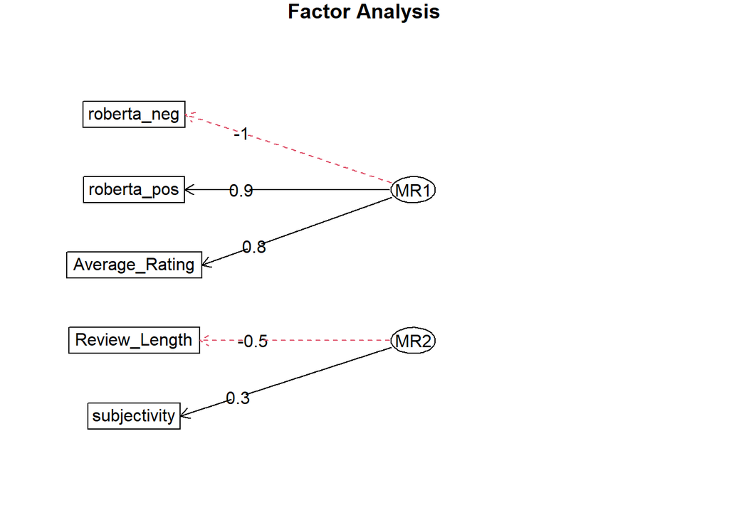

```r
# Cargar librerías necesarias
library(biotools)
library(MASS) # Para QDA

# Convertir la variable Recommended a factor
df_1_$Recommended <- as.factor(df_1_$Recommended)

# Modelo 1
# Variables seleccionadas para el modelo 1
continuous_columns_model1 <- c("vader_neg", "vader_pos", "vader_compound",
                               "Average_Rating", "Review_Length", "subjectivity", "vader_neu")

# Preparar datos del modelo 1
num_data_model1 <- df_1_[, c(continuous_columns_model1, "Recommended")]

# Prueba de igualdad de matrices de covarianza con Box's M
box_test_model1 <- boxM(num_data_model1[, continuous_columns_model1], num_data_model1$Recommended)
print(box_test_model1)
```

```
##
##  Box's M-test for Homogeneity of Covariance Matrices
##
## data:  num_data_model1[, continuous_columns_model1]
## Chi-Sq (approx.) = 3699.5, df = 28, p-value < 2.2e-16
```

```r
# Dividir datos en entrenamiento y prueba (70% entrenamiento, 30% prueba)
set.seed(123)
train_index_model1 <- sample(seq_len(nrow(num_data_model1)), size = 0.7 * nrow(num_data_model1))
train_data_model1 <- num_data_model1[train_index_model1, ]
test_data_model1 <- num_data_model1[-train_index_model1, ]

# modelo QDA
qda_model1 <- qda(Recommended ~ ., data = train_data_model1)
print(qda_model1)
```

```
## Call:
## qda(Recommended ~ ., data = train_data_model1)
##
## Prior probabilities of groups:
##        no       yes
## 0.6794085 0.3205915
##
## Group means:
##     vader_neg  vader_pos vader_compound Average_Rating Review_Length
## no  0.1173478 0.05720082     -0.4528984       1.800924      822.4123
## yes 0.0418564 0.18908355      0.7458074       4.246954      662.9913
##     subjectivity vader_neu
## no     0.4993231 0.8254616
## yes    0.5449374 0.7690574
```

```r
# Predecir en el conjunto de prueba
qda_pred_model1 <- predict(qda_model1, test_data_model1[, continuous_columns_model1])

# Evaluar el modelo: Matriz de confusión
confusion_matrix_model1 <- table(test_data_model1$Recommended, qda_pred_model1$class)
print(confusion_matrix_model1)
```

```
##
##         no  yes
##   no  1001   48
##   yes   47  440
```

```r
# Calcular la precisión del modelo
accuracy_model1 <- sum(diag(confusion_matrix_model1)) / sum(confusion_matrix_model1)
cat("Precisión del modelo QDA (Modelo 1):", round(accuracy_model1, 4), "\n")
```

```
## Precisión del modelo QDA (Modelo 1): 0.9382
```

- El modelo tiene un mejor desempeño del esperado en clasificar correctamente la variable “Recomended”. Sin embargo, hay un número similar de errores en ambas direcciones (48 y 47), lo que indica un modelo equilibrado en términos de sensibilidad y especificidad.
- Esto indica que vader a pesar que no es un modelo muy robusto, lográ aportar infomación adecuada sobre los sentimientos positivos y negativos de reviews. Aunque es importante observar que conociamos las probabilidades a priori puesto que la base de datos está desequilibrada a los comentarios negativos.

```r
# Modelo 2
# Variables seleccionadas para el modelo 2
continuous_columns_model2 <- c("roberta_neg", "roberta_pos",
                               "Average_Rating", "Review_Length", "subjectivity")

# Preparar datos del modelo 2
num_data_model2 <- df_1_[, c(continuous_columns_model2, "Recommended")]

# Prueba de igualdad de matrices de covarianza con Box's M
box_test_model2 <- boxM(num_data_model2[, continuous_columns_model2], num_data_model2$Recommended)
print(box_test_model2)
```

```
##
##  Box's M-test for Homogeneity of Covariance Matrices
##
## data:  num_data_model2[, continuous_columns_model2]
## Chi-Sq (approx.) = 5614.3, df = 15, p-value < 2.2e-16
```

```r
# Dividir datos en entrenamiento y prueba (70% entrenamiento, 30% prueba)
set.seed(123)
train_index_model2 <- sample(seq_len(nrow(num_data_model2)), size = 0.7 * nrow(num_data_model2))
train_data_model2 <- num_data_model2[train_index_model2, ]
test_data_model2 <- num_data_model2[-train_index_model2, ]

# modelo QDA
qda_model2 <- qda(Recommended ~ ., data = train_data_model2)
print(qda_model2)
```

```
## Call:
## qda(Recommended ~ ., data = train_data_model2)
##
## Prior probabilities of groups:
##        no       yes
## 0.6794085 0.3205915
##
## Group means:
##     roberta_neg roberta_pos Average_Rating Review_Length subjectivity
## no    0.8142022  0.04070858       1.800924      822.4123    0.4993231
## yes   0.1006590  0.76057065       4.246954      662.9913    0.5449374
```

```r
# Predecir en el conjunto de prueba
qda_pred_model2 <- predict(qda_model2, test_data_model2[, continuous_columns_model2])

# Evaluar el modelo: Matriz de confusión
confusion_matrix_model2 <- table(test_data_model2$Recommended, qda_pred_model2$class)
print(confusion_matrix_model2)
```

```
##
##         no  yes
##   no  1016   33
##   yes   47  440
```

```r
# Calcular la precisión del modelo
accuracy_model2 <- sum(diag(confusion_matrix_model2)) / sum(confusion_matrix_model2)
cat("Precisión del modelo QDA (Modelo 2):", round(accuracy_model2, 4), "\n")
```

```
## Precisión del modelo QDA (Modelo 2): 0.9479
```

# Conclusiones

- Dado que las variables no pasaron las pruebas de normalidad (univariada y multivariada), fue necesario realizar un modelamiento complementario utilizando técnicas como análisis de componentes principales (PCA), análisis factorial, análisis de clústeres y análisis discriminante cuadrático (QDA). El objetivo principal de este enfoque fue evaluar el comportamiento de los modelos y su capacidad para clasificar adecuadamente las opiniones de los usuarios.
- En el análisis descriptivo, se observó que VADER, a pesar de ser un modelo menos robusto que RoBERTa, presentó dificultades para diferenciar entre comentarios positivos y negativos, clasificando una gran cantidad de reseñas como neutrales. Esto generaba dudas sobre su desempeño en tareas más complejas de clasificación.
- PCA permitió reducir la dimensionalidad del conjunto de datos al identificar los ejes principales que explican la mayor parte de la varianza de las variables originales. y observar la clara separación que lograron generar los modelos de vader y roberta sobre los reviews.
- Analisis factorial: Ambos análisis muestran que la polaridad (positividad/negatividad) es el factor más importante (MR1). El segundo factor (MR2) está relacionado con características textuales como longitud y subjetividad.
- Aunque RoBERTa es más robusto y redujo errores, los modelos basados en VADER se desempeñaron sorprendentemente bien, probablemente porque el conjunto de datos es explícito en términos de polaridad del sentimiento y calificaciones.

-En general, los análisis realizados permitieron confirmar que tanto VADER como RoBERTa son herramientas útiles, y que VADER puede ser adecuado para tareas donde la interpretación de sentimientos sea menos compleja. Esto resalta la importancia de complementar los análisis descriptivos con modelamientos más avanzados para evaluar objetivamente el rendimiento de los modelos.